# Chancen und Herausforderungen von Werbereichweiten bei O<sub>2</sub> für die Jahre 2016 und 2017 anhand von getrackten Personendaten

Kework K. Kalustian

k.kalustian@gmx.de

### Key Insights zur Werbe-Reichweite von O<sub>2</sub>-Werbe-Content-Ausspielungen in 2016 und 2017

Werbe-Content-Ausspielungen im TV sind die wichtigsten Treiber, um Werbe-Erinnerungen zu generieren - gefolgt von Ausspielungen im Online-Bereich.

- Medienkontakte in verschiedenen Touchpoint-Channels, saisonale Informationen sowie personenspezifische Angaben sind zuverlässige Prädiktoren, um bestimmen zu können, ob und inwiefern eine Werbe-Erinnerung wahrscheinlich ist.
- Sowohl in 2016 als auch in 2017 zeigen sich signifikante Unterschiedseffekte zwischen Werbe-Erinnernden und Nicht-Werbe-Erinnernden in Bezug auf die Häufigkeiten der Medienkontakte pro Medium.

# Herausforderung

Werbewirksamkeit ist entscheidend, wenn Reichweiten und damit Umsätze gesteigert werden sollen. Die Herausforderung ist allerdings, dass die Mediennutzung immer fragmentierter stattfindet und Kund:innen über verschiedene Touchpoints und Medienformate unterschiedlich stark angesprochen werden. Eine Erfassung einer integrativen Customer Journey, bei der die Effizenz von Touchpoints identifiziert werden kann, ist daher von großem Interesse, um gezielter Werbe-Content auszuspielen.

- Um dieser Herausforderung gerecht zu werden, sind Tracking-Daten zur Werbe-Erinnerung in Abhängigkeit von verschiedenen Medienformaten als Treiber besonders hilfreich, da sie auch einen Einblick über die Nutzungsüberschneidung von Medienformaten zulassen (vgl. [GIK 2021](https://gik.media/best-for-tracking/)).
- Wie gut lässt sich also eine (nicht) vorhandene Werbe-Erinnerung auf Basis von Medienkontakten pro Medium, Alter, Saisonalität sowie Personengewichtung (Alter, Geschlecht, Region) bestimmen/zuordnen?

# Lösung

Um diese Leitfrage auf Basis von Personendaten in Bezug auf die O<sub>2</sub>-Werbe-Reichweite in den Jahren 2016 und 2017 beantworten zu können, wurde ein baumbasierter Klassifikator (Random Forest) modelliert, validiert (holdout-Methode) und getestet, nachdem die Datenqualität sichergestellt wurde.

- Zur Bestimmung der Medienwirksamkeit für das potentielle Vorliegen einer Werbe-Erinnerung wurden Wichtigkeiten verschiedener Input-Variablen berechnet.
- Derartig berechnete Wichtigkeiten sind ein hilfreiches Tool für künftige Werbekampagnen, da bestimmte Medienformate (z.B. Ads in TV, online, auf Plakaten oder online in Social Media, im Radio oder schließlich in Printformaten) gezielter eingesetzt werden können.

*Abbildung 1.* Variablen-Wichtigkeit bei der Zuordnung, ob potentiell eine Werbe-Erinnerung vorliegt.

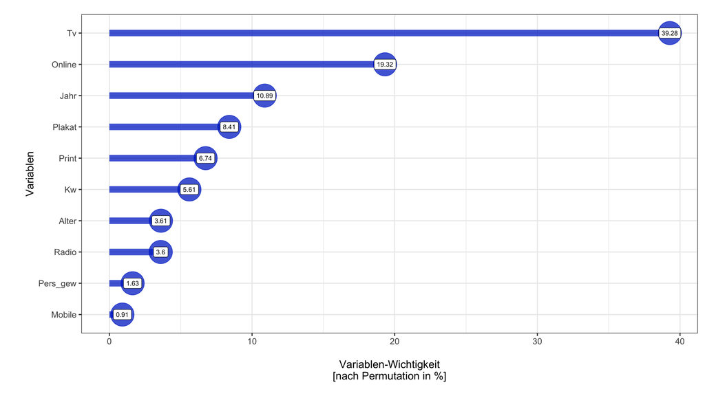

- Deutlich zu sehen ist hier, dass Ausspielungen von Werbe-Content im TV in den Jahren 2016 und 2017 mit großem Abstand wichtiger sind als z.B. online, wenn es darum geht, potentielle Werbe-Erinnerungen zu generieren.

Wenn die Medienkontakte pro Medienformat nach den Jahren 2016 und 2017 getrennt angeschaut werden, fällt allerdings auf, dass 2016 die mobilen Medienkontakte entweder nicht berichtet wurden (45.98 %) oder nicht vorlagen.

- Allerdings gibt es jedoch schwache (für 2016) und starke signifikante Unterschiedseffekte (für 2017) zwischen einer vorliegenden und nicht-vorliegenden Werbe-Erinnerung pro Medium (gemäß Dunn-Test mit Alpha-Fehler-Korrektur; die Mobile-Kontakte von 2016 konnten nicht berücksichtigt werden).

*Abbildung 2.* Medienkontakte pro Medienformat gruppiert nach vorhandener Werbe-Erinnerung und nach Jahren getrennt.

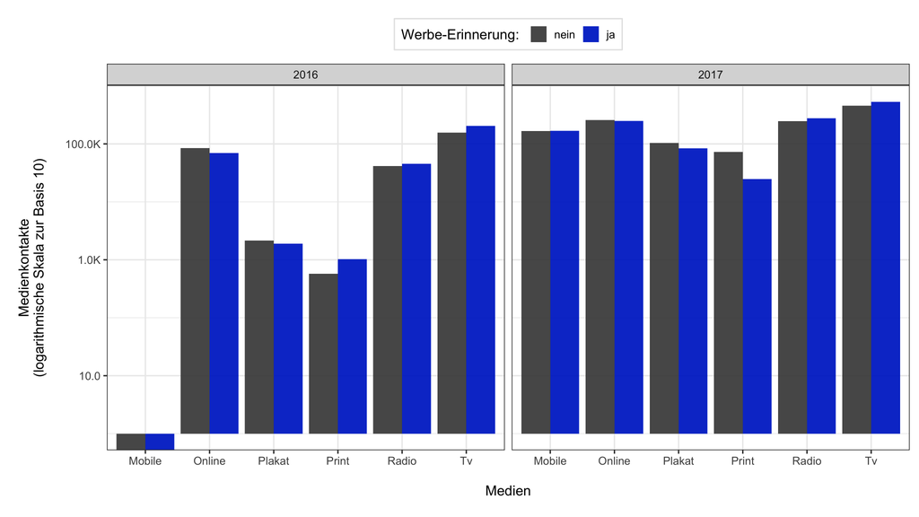

# Ergebnis

Durch den Einsatz von Machine Learning-Algorithmen bei großen Datensätzen sind nun die Treiber zur Erreichung einer potentiellen Werbe-Erinnerung identifiziert und können so priorisiert werden. Hiermit kann also O<sub>2</sub> effizienter und ressourcenschonender Kund:innen in Zukunft erreichen. Diese Klassifikatonsmethode zeigt eine Güte von über 86 % auf.

*Abbildung 3.* Modell-Güte bei der Zuordnung, ob bei (potentiellen) Kund:innen eine Werbe-Erinnerung vorliegt.

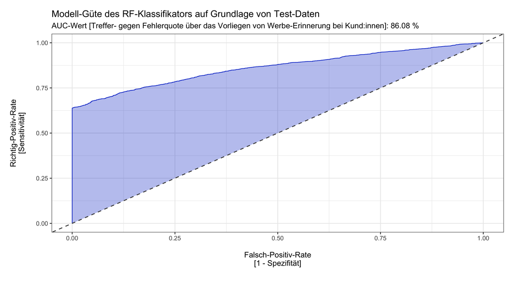

# Ausblick & How-To-Info

Eine höhere Güte könnte in Zukunft z.B. durch weitere Tracking-Dimensionen wie etwa Markenbekanntheit und -präferenz sowie durch weitere soziodemografische Angaben (Geschlechtsgruppe) und damit mit einer differenzierteren Segmentierung erfolgen.

- Außerdem könnten mit Regressions-Algorithmen z.B. Wahrscheinlichkeiten zur Werbe-Reichweite im Sinne eines anteiligen Verhältnisses zwischen ausgespieltem Werbe-Content und bestehender Werbe-Erinnerung (z.B. getrackt durch Likes oder Shares in Social Media) genauer bestimmt werden (vgl. Engagement-Rate).

Vielen Dank!